## MLB Spread Analysis

### Introduction

In Major League Baseball, managers (coaches) are responsible for submitting lineups before every game. Ignoring teams that are purposely tanking, managers need to account for the opposing teams pitcher and batters. Stats such as ERA, Batting Average, Slugging, On Base Percentage, etc are considered while trying to construct a lineup. A possible way to construct such a lineup is to project a score or the spread of the game to see how each pitcher/batting line up matches up against another team. In this project, we explore data currated from Retrosheet in an attempt to map baseball offensive and defensive stats to a projected spread.

### Data Set

The Retrosheet data set is a community driven database that keeps track of a wealth of detail about every game played since 1953. Each game contains information about every pitcher used, the scores after each innning, number of double plays, and even the umpires judging each game. For this project we’ll look just at data from last season 2017 which can be downloaded from http://www.retrosheet.org/gamelogs/index.html

### Setup

Before we can start our analysis, we import a couple of R packages to assist in the process.

```r
library(tidyverse)
library(stats)
library(broom)
```

### Import Data

When you first download the 2017 game log file, it will be zipped up. First unzip and a .txt file will come out. Change the txt file to a csv and then we’re good to roll.

```r
# load csv
game_df <- read.csv("GL2017.csv", header = FALSE, sep=",")
game_df %>%
    head() %>%
    select(V1:V6)
```

```
##         V1 V2  V3  V4 V5 V6
## 1 20170402  0 Sun SFN NL  1
## 2 20170402  0 Sun CHN NL  1
## 3 20170402  0 Sun NYA AL  1
## 4 20170403  0 Mon PHI NL  1
## 5 20170403  0 Mon SDN NL  1
## 6 20170403  0 Mon COL NL  1
```

Here we see the first couple of rows. There are actually 161 columns worth of data but we shorten it down just so we get a glimpse of what the data set is here. A lot of these are very specific and we wont be using them in our analysis but for those who are interested [here](http://www.retrosheet.org/gamelogs/glfields.txt) is the full breakdown of what each column represents.

### Tidying Data

```r
# select out important data from the main data frame
# mutate date to be a date type
tidied_df <- game_df %>%
    select(V1, V4, V7, V10, V11, V22, V23, V50, V51, V103, V105) %>%
    setNames(c("date", "away", "home", "away_score", "home_score", "away_ab", "away_hits", "home_ab", "home_hits", "away_pitcher", "home_pitcher")) %>%
    mutate(date = as.Date(as.character(date), "%Y%m%d")) %>%
    mutate(away_ba = away_hits/away_ab) %>%
    mutate(home_ba = home_hits/home_ab)

tidied_df %>%
    head()
```

```
##         date away home away_score home_score away_ab away_hits home_ab
## 1 2017-04-02  SFN  ARI          5          6      34        11      38
## 2 2017-04-02  CHN  SLN          3          4      34         8      35
## 3 2017-04-02  NYA  TBA          3          7      36         9      36
## 4 2017-04-03  PHI  CIN          4          3      35        10      32
## 5 2017-04-03  SDN  LAN          3         14      33         5      36
## 6 2017-04-03  COL  MIL          7          5      34        10      31
##   home_hits      away_pitcher    home_pitcher   away_ba   home_ba
## 1        13 Madison Bumgarner    Zack Greinke 0.3235294 0.3421053
## 2        11        Jon Lester Carlos Martinez 0.2352941 0.3142857
## 3        13   Masahiro Tanaka    Chris Archer 0.2500000 0.3611111
## 4         9 Jeremy Hellickson   Scott Feldman 0.2857143 0.2812500
## 5        14    Jhoulys Chacin Clayton Kershaw 0.1515152 0.3888889
## 6         7          Jon Gray   Junior Guerra 0.2941176 0.2258065
```

We tidied up our data down to a few columns that we’re going to need for this project. We have all the scores of each team and their at bat and hit counts. We’ve made some simiplifying assumptions like a pitcher’s ERA is just the score of the game but we’ll talk more about that later on.

### Data Exploration

Before creating our regression we look at how pitching and batting stats normalize throughout the season. We expect to see both these values normalize by the end of the regular season.

#### Pitching ERA

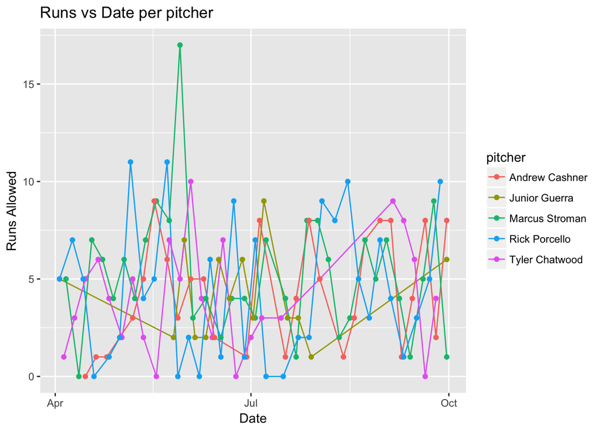

```r
# merge home and away pitcher eras together and graph based on date

pitch_df <- tidied_df %>%
    select(date, away_score, away_pitcher) %>%
    setNames(c("date", "runs", "pitcher"))

temp_df <- tidied_df %>%
    select(date, home_score, home_pitcher) %>%
    setNames(c("date", "runs", "pitcher"))

pitch_df <- rbind(pitch_df, temp_df)

# get 5 pitchers and graph their dates vs runs
pitchers <- pitch_df %>%
    select(pitcher) %>%
    sample_n(5)

pitch_df %>%
    filter(pitcher %in% unlist(pitchers)) %>%
    ggplot(aes(x=date, y=runs, group=pitcher)) +
        geom_line(aes(color=pitcher)) +
        geom_point(aes(color=pitcher)) +
        labs(title="Runs vs Date per pitcher", x="Date", y="Runs Allowed")
```

Here we see there doesnt seem to be much normalization. Runs jump all over the place. A lot of this seems to deal with luck so we’ll look at pitchers averages through each game.

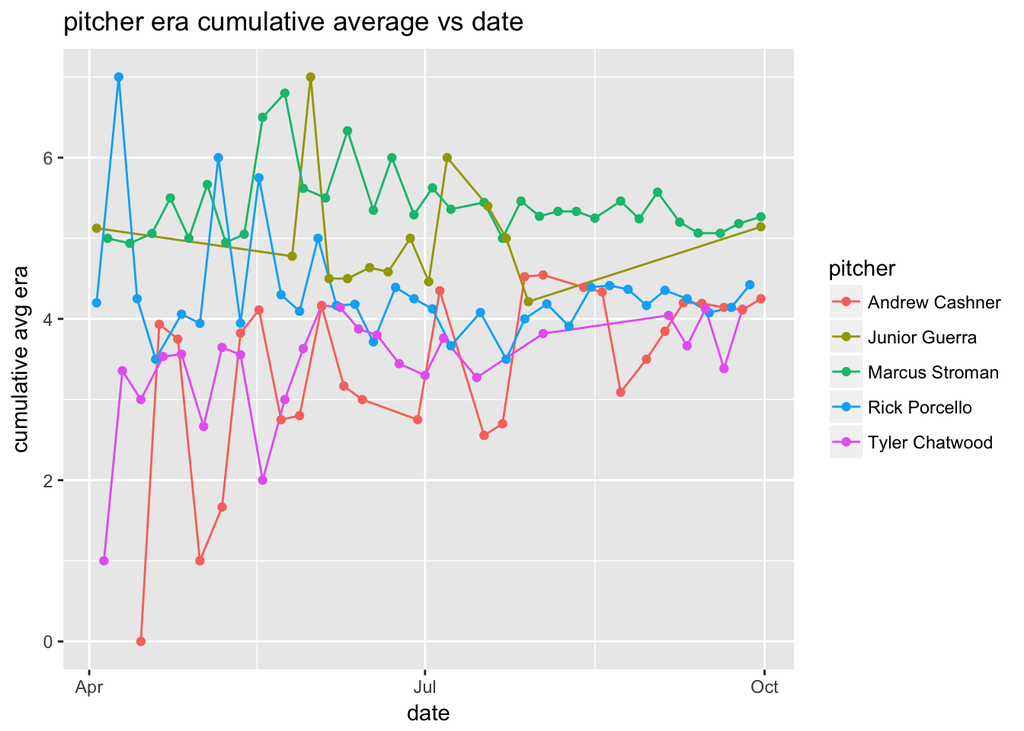

```r
# Look at the cumulative average of pitchers through games
pitch_df %>%
    filter(pitcher %in% unlist(pitchers)) %>%
    mutate(avg_runs = ave(runs, pitcher, FUN = cummean)) %>%
    ggplot(aes(x=date, y=avg_runs, group=pitcher)) +
        geom_line(aes(color=pitcher)) +
        geom_point(aes(color=pitcher)) +
        labs(title = "pitcher era cumulative average vs date", x="date", y = "cumulative avg era")
```

Now we start to see a bit of a normalization towards a number. This means that the more times a pitcher appears, the more we confident we are in his actual earned run average. Now lets look at the cumulative standard deviation for these pitchers as the season goes on.

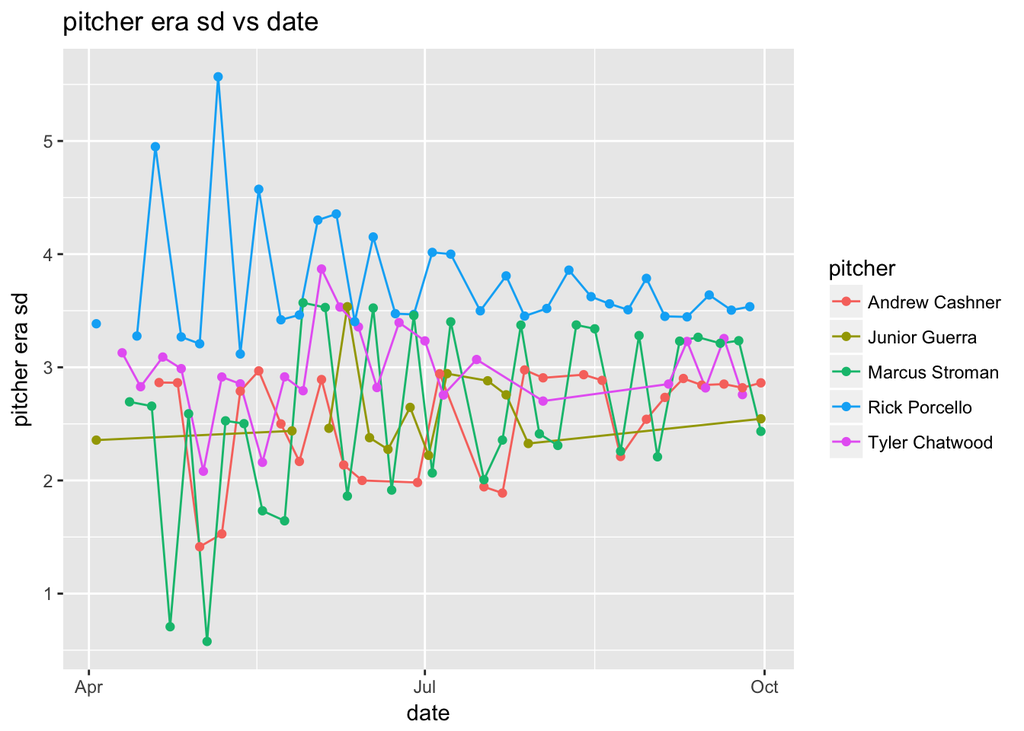

```r
cumsd <- function(x) unlist(sapply(sapply(seq_along(x), head, x=x), sd))

pitch_df %>%
    filter(pitcher %in% unlist(pitchers)) %>%
    mutate(run_sd = ave(runs, pitcher, FUN = cumsd)) %>%
    ggplot(aes(x=date, y=run_sd, group=pitcher)) +
        geom_line(aes(color=pitcher)) +
        geom_point(aes(color=pitcher)) +
        labs(title = "pitcher era sd vs date", x= "date", y = "pitcher era sd")
```

#### Batting Average

Here we’ll do the same thing as for pitchers but look at a teams overall batting average instead.

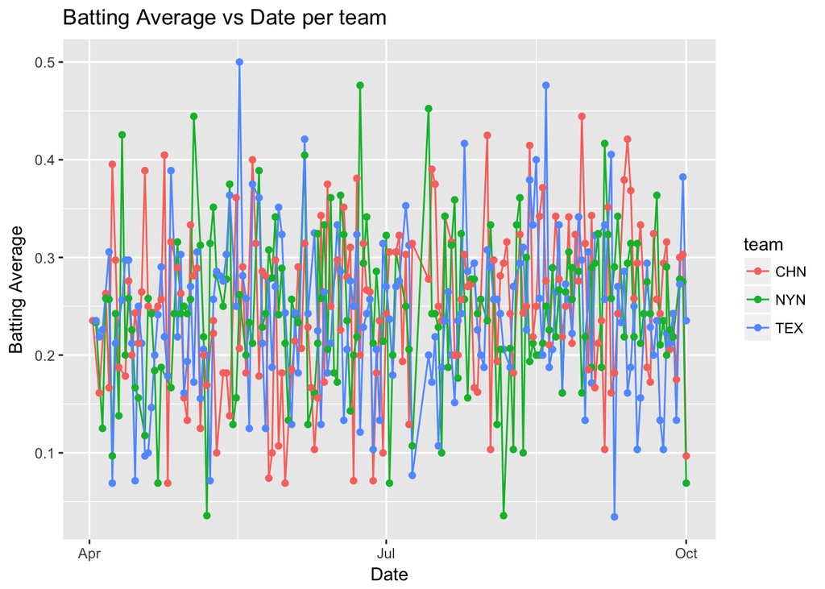

```r
# merge home and away batting stats together and graph based on date

bat_df <- tidied_df %>%
    select(date, away, away_ab, away_hits) %>%
    setNames(c("date", "team", "ab", "hit"))

temp_df <- tidied_df %>%
    select(date, home, home_ab, home_hits) %>%
    setNames(c("date", "team", "ab", "hit"))

bat_df <- rbind(bat_df, temp_df)

bat_df <- bat_df %>%
    mutate(batting_avg = hit/ab)

teams <- bat_df %>%
    select(team) %>%
    sample_n(3)

bat_df %>%
    filter(team %in% unlist(teams)) %>%
    ggplot(aes(x=date, y=batting_avg, group=team)) +
        geom_line(aes(color=team)) +
        geom_point(aes(color=team)) +
        labs(title="Batting Average vs Date per team", x="Date", y="Batting Average")
```

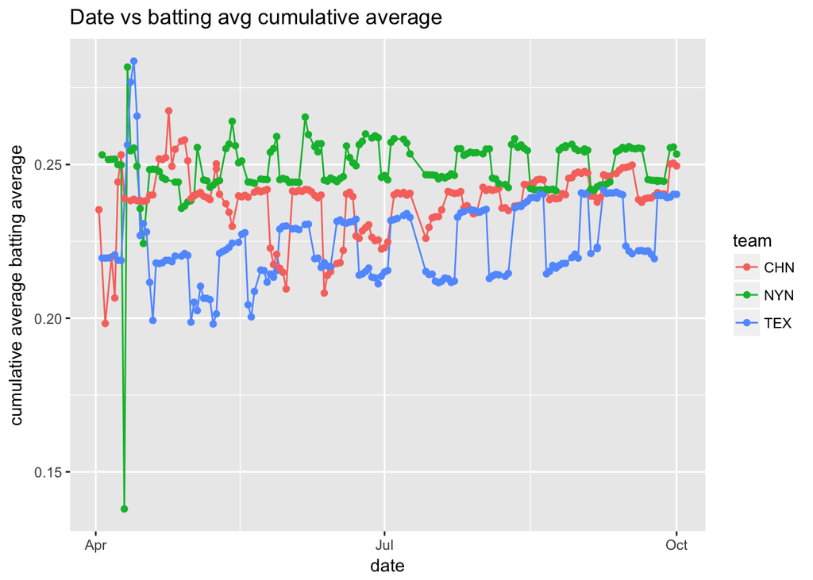

```r
bat_df %>%
    filter(team %in% unlist(teams)) %>%
    mutate(avg_ba = ave(batting_avg, team, FUN = cummean)) %>%
    ggplot(aes(x=date, y=avg_ba, group=team)) +
        geom_line(aes(color=team)) +
        geom_point(aes(color=team)) +
        labs(title= "Date vs batting avg cumulative average", x = "date", y = "cumulative average batting average")
```

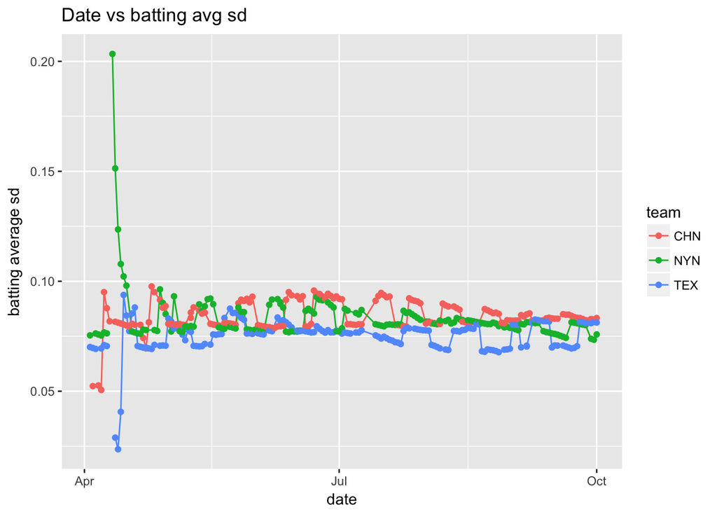

```r
bat_df %>%
    filter(team %in% unlist(teams)) %>%
    mutate(sd = ave(batting_avg, team, FUN = cumsd)) %>%
    ggplot(aes(x=date, y=sd, group=team)) +
        geom_line(aes(color=team)) +
        geom_point(aes(color=team)) +
        labs(title="Date vs batting avg sd", x = "date", y = "batting average sd")
```

#### Summary Statistics

```r
tidied_df %>%
    summary()
```

```
##       date                 away           home        away_score
##  Min.   :2017-04-02   ANA    :  81   ANA    :  81   Min.   : 0.000
##  1st Qu.:2017-05-19   ARI    :  81   ARI    :  81   1st Qu.: 2.000
##  Median :2017-07-01   ATL    :  81   ATL    :  81   Median : 4.000
##  Mean   :2017-07-03   BAL    :  81   BAL    :  81   Mean   : 4.539
##  3rd Qu.:2017-08-19   BOS    :  81   BOS    :  81   3rd Qu.: 6.000
##  Max.   :2017-10-01   CHA    :  81   CHA    :  81   Max.   :22.000
##                       (Other):1944   (Other):1944
##    home_score        away_ab        away_hits         home_ab
##  Min.   : 0.000   Min.   :23.00   Min.   : 0.000   Min.   :24.00
##  1st Qu.: 2.000   1st Qu.:32.00   1st Qu.: 6.000   1st Qu.:31.00
##  Median : 4.000   Median :34.00   Median : 8.000   Median :33.00
##  Mean   : 4.754   Mean   :34.81   Mean   : 8.684   Mean   :33.32
##  3rd Qu.: 7.000   3rd Qu.:37.00   3rd Qu.:11.000   3rd Qu.:35.00
##  Max.   :23.000   Max.   :67.00   Max.   :25.000   Max.   :65.00
##
##    home_hits                away_pitcher          home_pitcher
##  Min.   : 1.000   Jake Arrieta    :  20   Martin Perez  :  19
##  1st Qu.: 6.000   Chris Sale      :  19   Rick Porcello :  19
##  Median : 8.000   Ivan Nova       :  19   Jon Lester    :  18
##  Mean   : 8.688   Marco Estrada   :  19   Marcus Stroman:  18
##  3rd Qu.:11.000   Gerrit Cole     :  18   Mike Leake    :  18
##  Max.   :28.000   Justin Verlander:  18   R.A. Dickey   :  18
##                   (Other)         :2317   (Other)       :2320
##     away_ba          home_ba
##  Min.   :0.0000   Min.   :0.03226
##  1st Qu.:0.1875   1st Qu.:0.20000
##  Median :0.2424   Median :0.25611
##  Mean   :0.2431   Mean   :0.25620
##  3rd Qu.:0.2941   3rd Qu.:0.31034
##  Max.   :0.4902   Max.   :0.57143
##
```

Finally here is our summary statistics. Important stats to note here are the home and away scores and batting averages. When teams are at home, they have a slightly higher run and batting average.

### Regression

Now that we’ve looked at our data and know how data deviates around a central mean, we will use linear regression to see if there is a relationship between home and away pitching and batting average to calculate a potential outcome. The dependent variable in this experiment is the spread which is the away minus home score. The independent variables are the pitchers current era, the batters current batting average for home and away teams.

```r
tidied_df <- tidied_df %>%
    mutate(away_pitch_era = ave(away_score, away_pitcher, FUN = cummean)) %>%
    mutate(home_pitch_era = ave(home_score, home_pitcher, FUN = cummean)) %>%
    mutate(away_ba_avg = ave(away_ba, away, FUN = cummean)) %>%
    mutate(home_ba_avg = ave(home_ba, home, FUN = cummean)) %>%
    mutate(spread = away_score - home_score)

model = lm(spread ~ away_pitch_era + home_pitch_era + away_ba_avg + home_ba_avg, data=tidied_df)
```

#### Regression Analysis

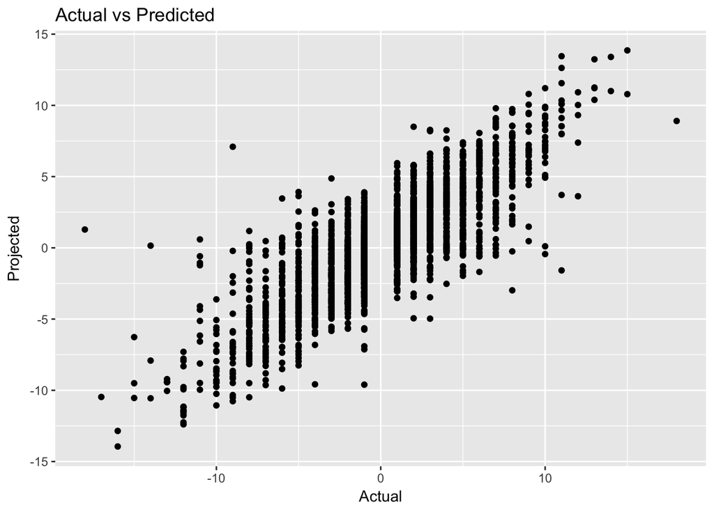

```r
model %>%
    augment() %>%
    ggplot(aes(x=spread, y=.resid)) +
        geom_point() +
        labs(title="Actual vs Predicted", x = "Actual", y = "Projected")
```

```r
model %>%
    tidy()
```

```
##             term   estimate  std.error   statistic      p.value
## 1    (Intercept)  0.1554885 1.28084599   0.1213952 9.033881e-01
## 2 away_pitch_era  1.0701958 0.04970053  21.5328842 2.975053e-94
## 3 home_pitch_era -0.9853332 0.04455114 -22.1169016 6.873373e-99
## 4    away_ba_avg -4.4745075 4.14358982  -1.0798626 2.803108e-01
## 5    home_ba_avg  1.7911239 3.93837589   0.4547874 6.493029e-01
```

### Data Problems

The project was simplified given the data available. There were some major assumptions made to statistics that are not necessarily true and may have caused issues in this project. First ERA is calculated from a pitchers runs allowed divided by innings pitched multiplied by 9. We made a simplification here by just assuming the end score was the pitcher’s ERA. In most games this is a safe assumption but in many, pitchers will only play 6-7 innings and record a couple of earned runs. Relief pitchers then come in to close out games and we captured their ERA into our starting pitcher era which is not true. Another simplification we made was assuming pitching ERA normalized after just one season (2017 for this project). A solid starting pitcher is given roughly 32 starts in an entire season which is not necessary enough for our data analysis.

### Conclusion

Projecting outcomes to MLB games is not an easy task. The best cappers for these predictions get about 53% correct given a cutoff line. We saw through our analysis that it is possible to project an outcome. Data trends towards a normal distribution which is what we want for a linear regression model. The more data that is used will give a better and more accurate representation of the model. Additionally adding more variables in to capture more advanced metrics could better capture the regression.